# Exploratory_analysis_property_price

```python
import pandas as pd
import matplotlib.pyplot as plt
import numpy as np
import matplotlib.pyplot as plt
import datetime
import seaborn as sb
import statsmodels.api as sm
from sklearn.model_selection import train_test_split

%matplotlib inline
```

```python
#read file
df = pd.read_csv('kc_house_data.csv')
```

## Data wrangling

### Data assessment

```python
df.sample(10)
```

|  | id | date | price | bedrooms | bathrooms | sqft_living | sqft_lot | floors | waterfront | view | ... | grade | sqft_above | sqft_basement | yr_built | yr_renovated | zipcode | lat | long | sqft_living15 | sqft_lot15 |
| --- | --- | --- | --- | --- | --- | --- | --- | --- | --- | --- | --- | --- | --- | --- | --- | --- | --- | --- | --- | --- | --- |
| 8917 | 5255000110 | 20141007T000000 | 460000.0 | 3 | 1.75 | 2560 | 8400 | 1.0 | 0 | 0 | ... | 7 | 1970 | 590 | 1959 | 0 | 98011 | 47.7668 | -122.197 | 1970 | 8400 |
| 12871 | 8146300180 | 20150512T000000 | 860000.0 | 5 | 2.25 | 1960 | 8592 | 1.0 | 0 | 0 | ... | 8 | 1290 | 670 | 1958 | 0 | 98004 | 47.6066 | -122.192 | 1720 | 8592 |
| 17698 | 2215900930 | 20140509T000000 | 225000.0 | 3 | 2.50 | 2000 | 9202 | 2.0 | 0 | 0 | ... | 7 | 2000 | 0 | 1992 | 0 | 98038 | 47.3516 | -122.057 | 1750 | 7827 |
| 7973 | 3122069029 | 20140619T000000 | 120000.0 | 2 | 1.00 | 990 | 39964 | 1.0 | 0 | 0 | ... | 4 | 990 | 0 | 1945 | 0 | 98042 | 47.3577 | -122.085 | 1560 | 8990 |
| 6285 | 1762600280 | 20140714T000000 | 1202500.0 | 3 | 2.50 | 3430 | 28718 | 1.5 | 0 | 0 | ... | 10 | 3430 | 0 | 1984 | 0 | 98033 | 47.6477 | -122.183 | 3440 | 35021 |
| 15695 | 3811000250 | 20140929T000000 | 610000.0 | 3 | 2.25 | 2320 | 38186 | 2.0 | 0 | 0 | ... | 8 | 2320 | 0 | 1980 | 0 | 98053 | 47.6645 | -122.068 | 2875 | 37523 |
| 1353 | 2423020260 | 20140814T000000 | 461000.0 | 3 | 2.25 | 1850 | 7923 | 1.0 | 0 | 0 | ... | 7 | 1150 | 700 | 1977 | 0 | 98033 | 47.7011 | -122.171 | 1780 | 7420 |
| 15917 | 6111400020 | 20150330T000000 | 410000.0 | 4 | 2.00 | 2010 | 9474 | 2.0 | 0 | 0 | ... | 7 | 2010 | 0 | 1953 | 2003 | 98166 | 47.4234 | -122.342 | 2140 | 10164 |
| 19894 | 1422069070 | 20150507T000000 | 472000.0 | 3 | 2.50 | 1860 | 415126 | 2.0 | 0 | 0 | ... | 7 | 1860 | 0 | 2006 | 0 | 98038 | 47.3974 | -122.005 | 2070 | 54014 |
| 20657 | 3278611610 | 20140907T000000 | 379900.0 | 3 | 2.50 | 1800 | 2792 | 2.0 | 0 | 0 | ... | 8 | 1800 | 0 | 2011 | 0 | 98126 | 47.5442 | -122.371 | 1580 | 2617 |

10 rows × 21 columns

```python
#get info from the data
df.info()
```

```
<class 'pandas.core.frame.DataFrame'>
RangeIndex: 21613 entries, 0 to 21612
Data columns (total 21 columns):
id               21613 non-null int64
date             21613 non-null object
price            21613 non-null float64
bedrooms         21613 non-null int64
bathrooms        21613 non-null float64
sqft_living      21613 non-null int64
sqft_lot         21613 non-null int64
floors           21613 non-null float64
waterfront       21613 non-null int64
view             21613 non-null int64
condition        21613 non-null int64
grade            21613 non-null int64
sqft_above       21613 non-null int64
sqft_basement    21613 non-null int64
yr_built         21613 non-null int64
yr_renovated     21613 non-null int64
zipcode          21613 non-null int64
lat              21613 non-null float64
long             21613 non-null float64
sqft_living15    21613 non-null int64
sqft_lot15       21613 non-null int64
dtypes: float64(5), int64(15), object(1)
memory usage: 3.5+ MB
```

```python
print('date has type: ', type(df.date[1]))
```

```
date has type:  <class 'str'>
```

```python
df.isna().sum() #Check for nan
```

```
id               0
date             0
price            0
bedrooms         0
bathrooms        0
sqft_living      0
sqft_lot         0
floors           0
waterfront       0
view             0
condition        0
grade            0
sqft_above       0
sqft_basement    0
yr_built         0
yr_renovated     0
zipcode          0
lat              0
long             0
sqft_living15    0
sqft_lot15       0
dtype: int64
```

*note:* does not have missing data. date column needs to be converted to datatype.

```python
#calculate descriptive statistics
df.describe()
```

|  | id | price | bedrooms | bathrooms | sqft_living | sqft_lot | floors | waterfront | view | condition | grade | sqft_above | sqft_basement | yr_built | yr_renovated | zipcode | lat | long | sqft_living15 | sqft_lot15 |
| --- | --- | --- | --- | --- | --- | --- | --- | --- | --- | --- | --- | --- | --- | --- | --- | --- | --- | --- | --- | --- |
| count | 2.161300e+04 | 2.161300e+04 | 21613.000000 | 21613.000000 | 21613.000000 | 2.161300e+04 | 21613.000000 | 21613.000000 | 21613.000000 | 21613.000000 | 21613.000000 | 21613.000000 | 21613.000000 | 21613.000000 | 21613.000000 | 21613.000000 | 21613.000000 | 21613.000000 | 21613.000000 | 21613.000000 |
| mean | 4.580302e+09 | 5.400881e+05 | 3.370842 | 2.114757 | 2079.899736 | 1.510697e+04 | 1.494309 | 0.007542 | 0.234303 | 3.409430 | 7.656873 | 1788.390691 | 291.509045 | 1971.005136 | 84.402258 | 98077.939805 | 47.560053 | -122.213896 | 1986.552492 | 12768.455652 |
| std | 2.876566e+09 | 3.671272e+05 | 0.930062 | 0.770163 | 918.440897 | 4.142051e+04 | 0.539989 | 0.086517 | 0.766318 | 0.650743 | 1.175459 | 828.090978 | 442.575043 | 29.373411 | 401.679240 | 53.505026 | 0.138564 | 0.140828 | 685.391304 | 27304.179631 |
| min | 1.000102e+06 | 7.500000e+04 | 0.000000 | 0.000000 | 290.000000 | 5.200000e+02 | 1.000000 | 0.000000 | 0.000000 | 1.000000 | 1.000000 | 290.000000 | 0.000000 | 1900.000000 | 0.000000 | 98001.000000 | 47.155900 | -122.519000 | 399.000000 | 651.000000 |
| 25% | 2.123049e+09 | 3.219500e+05 | 3.000000 | 1.750000 | 1427.000000 | 5.040000e+03 | 1.000000 | 0.000000 | 0.000000 | 3.000000 | 7.000000 | 1190.000000 | 0.000000 | 1951.000000 | 0.000000 | 98033.000000 | 47.471000 | -122.328000 | 1490.000000 | 5100.000000 |
| 50% | 3.904930e+09 | 4.500000e+05 | 3.000000 | 2.250000 | 1910.000000 | 7.618000e+03 | 1.500000 | 0.000000 | 0.000000 | 3.000000 | 7.000000 | 1560.000000 | 0.000000 | 1975.000000 | 0.000000 | 98065.000000 | 47.571800 | -122.230000 | 1840.000000 | 7620.000000 |
| 75% | 7.308900e+09 | 6.450000e+05 | 4.000000 | 2.500000 | 2550.000000 | 1.068800e+04 | 2.000000 | 0.000000 | 0.000000 | 4.000000 | 8.000000 | 2210.000000 | 560.000000 | 1997.000000 | 0.000000 | 98118.000000 | 47.678000 | -122.125000 | 2360.000000 | 10083.000000 |
| max | 9.900000e+09 | 7.700000e+06 | 33.000000 | 8.000000 | 13540.000000 | 1.651359e+06 | 3.500000 | 1.000000 | 4.000000 | 5.000000 | 13.000000 | 9410.000000 | 4820.000000 | 2015.000000 | 2015.000000 | 98199.000000 | 47.777600 | -121.315000 | 6210.000000 | 871200.000000 |

*note:*

- price might have outliers
- sqft_lot might have outliers
- sqft_living might have outliers
- sqft_above might have outliers
- sqft_basement might have outliers

Check for duplicated numbers:

```python
df.duplicated().sum()
```

```
0
```

*Note:* duplicated values are not found

```python
#check the number of rooms count
df.bedrooms.value_counts()
```

```
3     9824
4     6882
2     2760
5     1601
6      272
1      199
7       38
8       13
0       13
9        6
10       3
11       1
33       1
Name: bedrooms, dtype: int64
```

```python
#check the number of bathrooms count
df.bathrooms.value_counts()
```

```
2.50    5380
1.00    3852
1.75    3048
2.25    2047
2.00    1930
1.50    1446
2.75    1185
3.00     753
3.50     731
3.25     589
3.75     155
4.00     136
4.50     100
4.25      79
0.75      72
4.75      23
5.00      21
5.25      13
0.00      10
5.50      10
1.25       9
6.00       6
0.50       4
5.75       4
8.00       2
6.25       2
6.50       2
6.75       2
7.50       1
7.75       1
Name: bathrooms, dtype: int64
```

*note:* Number of bathrooms per house has fractional numbers. It looks like it is meaningful for this dataset. Check dataset for 5.25, 0, 5.5, 1.25, 6, 0.5, 5.75, 8, 6.25, 6.5, 6.75, 7.5, 7.75 - this numbers have a low number of occurance

```python
#check the number of bathrooms count
df.floors.value_counts()
```

```
1.0    10680
2.0     8241
1.5     1910
3.0      613
2.5      161
3.5        8
Name: floors, dtype: int64
```

```python
df.isna().sum()
```

```
id               0
date             0
price            0
bedrooms         0
bathrooms        0
sqft_living      0
sqft_lot         0
floors           0
waterfront       0
view             0
condition        0
grade            0
sqft_above       0
sqft_basement    0
yr_built         0
yr_renovated     0
zipcode          0
lat              0
long             0
sqft_living15    0
sqft_lot15       0
dtype: int64
```

note: Number of floors per house has fractional numbers. It looks like it is meaningful for this dataset. Check dataset for 3.5 floors, it has a low number of occurance

```python
# are 0, 8, 9, 10, 11, 33 number of rooms outliers?
#take a look at them in the dataset. Also include bathrooms

df.query('bedrooms == [0, 8, 9, 10, 11, 33] | bathrooms == [5.25, 0, 5.5, 1.25, 6, 0.5, 5.75, 8, 6.25, 6.5, 6.75, 7.5, 7.75]')
```

|  | id | date | price | bedrooms | bathrooms | sqft_living | sqft_lot | floors | waterfront | view | ... | grade | sqft_above | sqft_basement | yr_built | yr_renovated | zipcode | lat | long | sqft_living15 | sqft_lot15 |
| --- | --- | --- | --- | --- | --- | --- | --- | --- | --- | --- | --- | --- | --- | --- | --- | --- | --- | --- | --- | --- | --- |
| 875 | 6306400140 | 20140612T000000 | 1095000.0 | 0 | 0.00 | 3064 | 4764 | 3.5 | 0 | 2 | ... | 7 | 3064 | 0 | 1990 | 0 | 98102 | 47.6362 | -122.322 | 2360 | 4000 |
| 972 | 1455100116 | 20150202T000000 | 397500.0 | 3 | 1.25 | 1510 | 13737 | 1.0 | 0 | 3 | ... | 6 | 810 | 700 | 1961 | 0 | 98125 | 47.7289 | -122.283 | 2560 | 10202 |
| 1149 | 3421079032 | 20150217T000000 | 75000.0 | 1 | 0.00 | 670 | 43377 | 1.0 | 0 | 0 | ... | 3 | 670 | 0 | 1966 | 0 | 98022 | 47.2638 | -121.906 | 1160 | 42882 |
| 1164 | 1247600105 | 20141020T000000 | 5110800.0 | 5 | 5.25 | 8010 | 45517 | 2.0 | 1 | 4 | ... | 12 | 5990 | 2020 | 1999 | 0 | 98033 | 47.6767 | -122.211 | 3430 | 26788 |
| 1315 | 7558700030 | 20150413T000000 | 5300000.0 | 6 | 6.00 | 7390 | 24829 | 2.0 | 1 | 4 | ... | 12 | 5000 | 2390 | 1991 | 0 | 98040 | 47.5631 | -122.210 | 4320 | 24619 |
| 1660 | 9126101740 | 20141204T000000 | 490000.0 | 8 | 5.00 | 2800 | 2580 | 2.0 | 0 | 0 | ... | 8 | 1880 | 920 | 1997 | 0 | 98122 | 47.6086 | -122.303 | 1800 | 2580 |
| 1678 | 2658000335 | 20141027T000000 | 275000.0 | 3 | 1.25 | 1230 | 4500 | 1.5 | 0 | 0 | ... | 7 | 1230 | 0 | 1913 | 0 | 98118 | 47.5301 | -122.271 | 1310 | 5000 |
| 2261 | 3971701455 | 20141003T000000 | 273000.0 | 2 | 0.50 | 1180 | 7750 | 1.0 | 0 | 0 | ... | 6 | 590 | 590 | 1945 | 0 | 98155 | 47.7690 | -122.316 | 1380 | 8976 |
| 2626 | 7738500731 | 20140815T000000 | 4500000.0 | 5 | 5.50 | 6640 | 40014 | 2.0 | 1 | 4 | ... | 12 | 6350 | 290 | 2004 | 0 | 98155 | 47.7493 | -122.280 | 3030 | 23408 |
| 3020 | 3377900195 | 20140929T000000 | 2525000.0 | 4 | 5.50 | 6930 | 45100 | 1.0 | 0 | 0 | ... | 11 | 4310 | 2620 | 1950 | 1991 | 98006 | 47.5547 | -122.144 | 2560 | 37766 |
| 3100 | 622069006 | 20140820T000000 | 1500000.0 | 4 | 5.50 | 6550 | 217374 | 1.0 | 0 | 0 | ... | 11 | 5400 | 1150 | 2006 | 0 | 98058 | 47.4302 | -122.095 | 4110 | 50378 |
| 3119 | 3918400017 | 20150205T000000 | 380000.0 | 0 | 0.00 | 1470 | 979 | 3.0 | 0 | 2 | ... | 8 | 1470 | 0 | 2006 | 0 | 98133 | 47.7145 | -122.356 | 1470 | 1399 |
| 3121 | 7237500590 | 20141117T000000 | 1320000.0 | 4 | 5.25 | 6110 | 10369 | 2.0 | 0 | 0 | ... | 11 | 6110 | 0 | 2005 | 0 | 98059 | 47.5285 | -122.135 | 4190 | 10762 |
| 3467 | 1453602309 | 20140805T000000 | 288000.0 | 0 | 1.50 | 1430 | 1650 | 3.0 | 0 | 0 | ... | 7 | 1430 | 0 | 1999 | 0 | 98125 | 47.7222 | -122.290 | 1430 | 1650 |
| 3732 | 793200100 | 20141218T000000 | 360000.0 | 3 | 1.25 | 2350 | 6200 | 1.0 | 0 | 0 | ... | 7 | 1320 | 1030 | 1966 | 0 | 98007 | 47.5979 | -122.135 | 2140 | 9543 |
| 4024 | 9175600025 | 20141007T000000 | 800000.0 | 7 | 6.75 | 7480 | 41664 | 2.0 | 0 | 2 | ... | 11 | 5080 | 2400 | 1953 | 0 | 98166 | 47.4643 | -122.368 | 2810 | 33190 |
| 4035 | 685000115 | 20141007T000000 | 2150000.0 | 8 | 6.00 | 4340 | 9415 | 2.0 | 0 | 0 | ... | 8 | 4340 | 0 | 1967 | 0 | 98004 | 47.6316 | -122.202 | 2050 | 9100 |
| 4067 | 7226500100 | 20150219T000000 | 373000.0 | 8 | 3.00 | 2850 | 12714 | 1.0 | 0 | 0 | ... | 7 | 2850 | 0 | 1959 | 0 | 98055 | 47.4859 | -122.205 | 1480 | 4942 |
| 4096 | 1997200215 | 20140507T000000 | 599999.0 | 9 | 4.50 | 3830 | 6988 | 2.5 | 0 | 0 | ... | 7 | 2450 | 1380 | 1938 | 0 | 98103 | 47.6927 | -122.338 | 1460 | 6291 |
| 4149 | 6447300265 | 20141014T000000 | 4000000.0 | 4 | 5.50 | 7080 | 16573 | 2.0 | 0 | 0 | ... | 12 | 5760 | 1320 | 2008 | 0 | 98039 | 47.6151 | -122.224 | 3140 | 15996 |
| 4235 | 2902200015 | 20150106T000000 | 700000.0 | 9 | 3.00 | 3680 | 4400 | 2.0 | 0 | 0 | ... | 7 | 2830 | 850 | 1908 | 0 | 98102 | 47.6374 | -122.324 | 1960 | 2450 |
| 4411 | 2470100110 | 20140804T000000 | 5570000.0 | 5 | 5.75 | 9200 | 35069 | 2.0 | 0 | 0 | ... | 13 | 6200 | 3000 | 2001 | 0 | 98039 | 47.6289 | -122.233 | 3560 | 24345 |
| 4598 | 9297300740 | 20141118T000000 | 643500.0 | 6 | 5.25 | 3600 | 3960 | 2.0 | 0 | 0 | ... | 7 | 2400 | 1200 | 1971 | 0 | 98126 | 47.5656 | -122.372 | 1450 | 4600 |
| 4868 | 6896300380 | 20141002T000000 | 228000.0 | 0 | 1.00 | 390 | 5900 | 1.0 | 0 | 0 | ... | 4 | 390 | 0 | 1953 | 0 | 98118 | 47.5260 | -122.261 | 2170 | 6000 |
| 5024 | 98000950 | 20141210T000000 | 1060000.0 | 4 | 5.25 | 4140 | 14757 | 2.0 | 0 | 2 | ... | 11 | 4140 | 0 | 2005 | 0 | 98075 | 47.5871 | -121.969 | 4440 | 15523 |
| 5832 | 5702500050 | 20141104T000000 | 280000.0 | 1 | 0.00 | 600 | 24501 | 1.0 | 0 | 0 | ... | 3 | 600 | 0 | 1950 | 0 | 98045 | 47.5316 | -121.749 | 990 | 22549 |
| 6079 | 9822700190 | 20140808T000000 | 1280000.0 | 9 | 4.50 | 3650 | 5000 | 2.0 | 0 | 0 | ... | 8 | 2530 | 1120 | 1915 | 2010 | 98105 | 47.6604 | -122.289 | 2510 | 5000 |
| 6174 | 1873400020 | 20140703T000000 | 340000.0 | 8 | 2.75 | 2790 | 6695 | 1.0 | 0 | 0 | ... | 7 | 1470 | 1320 | 1977 | 0 | 98133 | 47.7565 | -122.331 | 1760 | 7624 |
| 6501 | 2626069030 | 20150209T000000 | 1940000.0 | 4 | 5.75 | 7220 | 223462 | 2.0 | 0 | 4 | ... | 12 | 6220 | 1000 | 2000 | 0 | 98053 | 47.7097 | -122.013 | 2680 | 7593 |
| 6994 | 2954400190 | 20140624T000000 | 1295650.0 | 0 | 0.00 | 4810 | 28008 | 2.0 | 0 | 0 | ... | 12 | 4810 | 0 | 1990 | 0 | 98053 | 47.6642 | -122.069 | 4740 | 35061 |
| ... | ... | ... | ... | ... | ... | ... | ... | ... | ... | ... | ... | ... | ... | ... | ... | ... | ... | ... | ... | ... | ... |
| 16773 | 1630700380 | 20150130T000000 | 1920000.0 | 5 | 5.75 | 7730 | 230868 | 2.0 | 0 | 0 | ... | 12 | 6660 | 1070 | 2004 | 0 | 98077 | 47.7615 | -122.084 | 2660 | 39292 |
| 16803 | 7116500920 | 20140520T000000 | 300000.0 | 6 | 5.25 | 2860 | 5682 | 2.0 | 0 | 0 | ... | 7 | 2860 | 0 | 1978 | 0 | 98002 | 47.3030 | -122.221 | 1390 | 5956 |
| 16840 | 955000430 | 20140903T000000 | 540000.0 | 2 | 1.25 | 1230 | 1569 | 2.0 | 0 | 0 | ... | 9 | 1050 | 180 | 2009 | 0 | 98112 | 47.6193 | -122.304 | 1100 | 1230 |
| 16844 | 8823900290 | 20150317T000000 | 1400000.0 | 9 | 4.00 | 4620 | 5508 | 2.5 | 0 | 0 | ... | 11 | 3870 | 750 | 1915 | 0 | 98105 | 47.6684 | -122.309 | 2710 | 4320 |
| 16969 | 3025059093 | 20140729T000000 | 3100000.0 | 5 | 5.25 | 5090 | 23669 | 2.0 | 0 | 0 | ... | 12 | 5090 | 0 | 2006 | 0 | 98004 | 47.6297 | -122.216 | 3830 | 22605 |
| 17235 | 1338600225 | 20140528T000000 | 1970000.0 | 8 | 3.50 | 4440 | 6480 | 2.0 | 0 | 3 | ... | 10 | 3140 | 1300 | 1959 | 0 | 98112 | 47.6310 | -122.303 | 4440 | 8640 |
| 17899 | 3262300555 | 20140708T000000 | 2458000.0 | 4 | 5.25 | 6500 | 14986 | 2.0 | 0 | 0 | ... | 11 | 5180 | 1320 | 2001 | 0 | 98039 | 47.6304 | -122.236 | 2270 | 8119 |
| 18287 | 1524079188 | 20140729T000000 | 1862000.0 | 4 | 5.25 | 5240 | 320917 | 2.0 | 0 | 2 | ... | 10 | 5240 | 0 | 2006 | 0 | 98024 | 47.5605 | -121.905 | 1930 | 68824 |
| 18302 | 6072800246 | 20140702T000000 | 3300000.0 | 5 | 6.25 | 8020 | 21738 | 2.0 | 0 | 0 | ... | 11 | 8020 | 0 | 2001 | 0 | 98006 | 47.5675 | -122.189 | 4160 | 18969 |
| 18379 | 1222029077 | 20141029T000000 | 265000.0 | 0 | 0.75 | 384 | 213444 | 1.0 | 0 | 0 | ... | 4 | 384 | 0 | 2003 | 0 | 98070 | 47.4177 | -122.491 | 1920 | 224341 |
| 18427 | 4139900120 | 20140605T000000 | 1415000.0 | 4 | 5.25 | 4670 | 43950 | 2.0 | 0 | 0 | ... | 12 | 4670 | 0 | 1989 | 0 | 98006 | 47.5456 | -122.126 | 4900 | 35000 |
| 18443 | 8823901445 | 20150313T000000 | 934000.0 | 9 | 3.00 | 2820 | 4480 | 2.0 | 0 | 0 | ... | 7 | 1880 | 940 | 1918 | 0 | 98105 | 47.6654 | -122.307 | 2460 | 4400 |
| 18477 | 1346300150 | 20141020T000000 | 3300000.0 | 8 | 4.00 | 7710 | 11750 | 3.5 | 0 | 0 | ... | 12 | 6090 | 1620 | 1904 | 0 | 98112 | 47.6263 | -122.314 | 4210 | 8325 |
| 18655 | 9829201020 | 20141118T000000 | 1388000.0 | 3 | 1.25 | 2400 | 6653 | 3.0 | 0 | 2 | ... | 11 | 2400 | 0 | 1992 | 0 | 98122 | 47.6019 | -122.290 | 1910 | 6653 |
| 18975 | 1778360150 | 20140620T000000 | 1240000.0 | 7 | 5.50 | 6630 | 13782 | 2.0 | 0 | 0 | ... | 10 | 4930 | 1700 | 2004 | 0 | 98006 | 47.5399 | -122.118 | 4470 | 8639 |
| 19148 | 3625049042 | 20141011T000000 | 3635000.0 | 5 | 6.00 | 5490 | 19897 | 2.0 | 0 | 0 | ... | 12 | 5490 | 0 | 2005 | 0 | 98039 | 47.6165 | -122.236 | 2910 | 17600 |
| 19254 | 8812401450 | 20141229T000000 | 660000.0 | 10 | 3.00 | 2920 | 3745 | 2.0 | 0 | 0 | ... | 7 | 1860 | 1060 | 1913 | 0 | 98105 | 47.6635 | -122.320 | 1810 | 3745 |
| 19302 | 3756900027 | 20141125T000000 | 575000.0 | 8 | 3.00 | 3840 | 15990 | 1.0 | 0 | 0 | ... | 7 | 2530 | 1310 | 1961 | 0 | 98034 | 47.7111 | -122.211 | 1380 | 8172 |
| 19452 | 3980300371 | 20140926T000000 | 142000.0 | 0 | 0.00 | 290 | 20875 | 1.0 | 0 | 0 | ... | 1 | 290 | 0 | 1963 | 0 | 98024 | 47.5308 | -121.888 | 1620 | 22850 |
| 20096 | 3262300485 | 20150421T000000 | 2250000.0 | 5 | 5.25 | 3410 | 8118 | 2.0 | 0 | 0 | ... | 11 | 3410 | 0 | 2006 | 0 | 98039 | 47.6295 | -122.236 | 3410 | 16236 |
| 20233 | 5710000005 | 20140522T000000 | 2150000.0 | 4 | 5.50 | 5060 | 10320 | 2.0 | 0 | 0 | ... | 11 | 5060 | 0 | 2008 | 0 | 98004 | 47.6245 | -122.210 | 3010 | 10080 |
| 20452 | 1125079111 | 20150415T000000 | 1600000.0 | 4 | 5.50 | 6530 | 871200 | 2.0 | 0 | 2 | ... | 11 | 6530 | 0 | 2008 | 0 | 98014 | 47.6640 | -121.878 | 1280 | 858132 |
| 20578 | 424069279 | 20150328T000000 | 1180000.0 | 6 | 6.50 | 6260 | 10955 | 2.0 | 0 | 0 | ... | 11 | 4840 | 1420 | 2007 | 0 | 98075 | 47.5947 | -122.039 | 2710 | 12550 |
| 20701 | 7589700055 | 20140611T000000 | 545000.0 | 2 | 1.25 | 1240 | 2150 | 2.0 | 0 | 0 | ... | 8 | 1240 | 0 | 2014 | 0 | 98117 | 47.6884 | -122.374 | 1340 | 5289 |
| 20838 | 3425069117 | 20140828T000000 | 1275000.0 | 6 | 5.25 | 6160 | 27490 | 2.0 | 0 | 0 | ... | 11 | 4040 | 2120 | 2007 | 0 | 98074 | 47.6094 | -122.023 | 4225 | 9100 |
| 21050 | 2424059170 | 20150219T000000 | 900000.0 | 5 | 6.00 | 7120 | 40806 | 2.0 | 0 | 4 | ... | 12 | 5480 | 1640 | 2007 | 0 | 98006 | 47.5451 | -122.114 | 3440 | 36859 |
| 21065 | 1498301048 | 20140508T000000 | 321950.0 | 2 | 1.25 | 860 | 1277 | 2.0 | 0 | 0 | ... | 7 | 860 | 0 | 2007 | 0 | 98144 | 47.5842 | -122.314 | 1280 | 1265 |
| 21344 | 8835770170 | 20140822T000000 | 1488000.0 | 5 | 6.00 | 6880 | 279968 | 2.0 | 0 | 3 | ... | 12 | 4070 | 2810 | 2007 | 0 | 98045 | 47.4624 | -121.779 | 4690 | 256803 |
| 21506 | 2524069097 | 20140509T000000 | 2238890.0 | 5 | 6.50 | 7270 | 130017 | 2.0 | 0 | 0 | ... | 12 | 6420 | 850 | 2010 | 0 | 98027 | 47.5371 | -121.982 | 1800 | 44890 |
| 21552 | 688000017 | 20140627T000000 | 516500.0 | 1 | 1.25 | 1100 | 638 | 3.0 | 0 | 0 | ... | 9 | 1100 | 0 | 2014 | 0 | 98112 | 47.6228 | -122.307 | 1110 | 1933 |

93 rows × 21 columns

```python
#Take a look a close attention to a row with bedrooms 33
df.query('bedrooms == 33')
```

|  | id | date | price | bedrooms | bathrooms | sqft_living | sqft_lot | floors | waterfront | view | ... | grade | sqft_above | sqft_basement | yr_built | yr_renovated | zipcode | lat | long | sqft_living15 | sqft_lot15 |
| --- | --- | --- | --- | --- | --- | --- | --- | --- | --- | --- | --- | --- | --- | --- | --- | --- | --- | --- | --- | --- | --- |
| 15870 | 2402100895 | 20140625T000000 | 640000.0 | 33 | 1.75 | 1620 | 6000 | 1.0 | 0 | 0 | ... | 7 | 1040 | 580 | 1947 | 0 | 98103 | 47.6878 | -122.331 | 1330 | 4700 |

1 rows × 21 columns

```python
df.query('bedrooms == 3').sample(3)
```

|  | id | date | price | bedrooms | bathrooms | sqft_living | sqft_lot | floors | waterfront | view | ... | grade | sqft_above | sqft_basement | yr_built | yr_renovated | zipcode | lat | long | sqft_living15 | sqft_lot15 |
| --- | --- | --- | --- | --- | --- | --- | --- | --- | --- | --- | --- | --- | --- | --- | --- | --- | --- | --- | --- | --- | --- |
| 19834 | 6817750140 | 20140708T000000 | 293000.0 | 3 | 2.25 | 1910 | 3481 | 2.0 | 0 | 0 | ... | 8 | 1910 | 0 | 2009 | 0 | 98055 | 47.4293 | -122.188 | 1714 | 3177 |
| 20023 | 301402120 | 20140625T000000 | 240000.0 | 3 | 2.25 | 1481 | 2820 | 2.0 | 0 | 0 | ... | 7 | 1481 | 0 | 2012 | 0 | 98002 | 47.3457 | -122.217 | 1481 | 3028 |
| 19861 | 7299600700 | 20150512T000000 | 328000.0 | 3 | 2.50 | 2242 | 4800 | 2.0 | 0 | 0 | ... | 8 | 2242 | 0 | 2013 | 0 | 98092 | 47.2581 | -122.200 | 2009 | 4800 |

3 rows × 21 columns

"0 bedrooms per house" does not make any sense. It looks like typos in the dataset. 33 bedroom appartment looks like a type and most probably it should 3 bedroom appartment. Either to change 33 to 3 or just drop this row?

```python
df.query('floors == 3.5 ')
```

|  | id | date | price | bedrooms | bathrooms | sqft_living | sqft_lot | floors | waterfront | view | ... | grade | sqft_above | sqft_basement | yr_built | yr_renovated | zipcode | lat | long | sqft_living15 | sqft_lot15 |
| --- | --- | --- | --- | --- | --- | --- | --- | --- | --- | --- | --- | --- | --- | --- | --- | --- | --- | --- | --- | --- | --- |
| 875 | 6306400140 | 20140612T000000 | 1095000.0 | 0 | 0.00 | 3064 | 4764 | 3.5 | 0 | 2 | ... | 7 | 3064 | 0 | 1990 | 0 | 98102 | 47.6362 | -122.322 | 2360 | 4000 |
| 10077 | 1972202010 | 20140801T000000 | 435000.0 | 3 | 3.00 | 1440 | 1350 | 3.5 | 0 | 2 | ... | 8 | 1440 | 0 | 2005 | 0 | 98103 | 47.6525 | -122.345 | 1440 | 1350 |
| 11594 | 3180100023 | 20150130T000000 | 544000.0 | 3 | 2.50 | 1760 | 1755 | 3.5 | 0 | 0 | ... | 8 | 1760 | 0 | 1998 | 0 | 98105 | 47.6688 | -122.279 | 1700 | 1721 |
| 14885 | 8673400177 | 20150402T000000 | 525000.0 | 3 | 3.00 | 1730 | 1074 | 3.5 | 0 | 0 | ... | 8 | 1730 | 0 | 2006 | 0 | 98107 | 47.6692 | -122.392 | 1370 | 1185 |
| 15424 | 1702900664 | 20150416T000000 | 479000.0 | 2 | 2.50 | 1730 | 1037 | 3.5 | 0 | 0 | ... | 8 | 1730 | 0 | 2008 | 0 | 98118 | 47.5594 | -122.285 | 1280 | 1026 |
| 18477 | 1346300150 | 20141020T000000 | 3300000.0 | 8 | 4.00 | 7710 | 11750 | 3.5 | 0 | 0 | ... | 12 | 6090 | 1620 | 1904 | 0 | 98112 | 47.6263 | -122.314 | 4210 | 8325 |
| 20308 | 1972200426 | 20140918T000000 | 525000.0 | 2 | 2.75 | 1310 | 1268 | 3.5 | 0 | 0 | ... | 8 | 1310 | 0 | 2007 | 0 | 98103 | 47.6534 | -122.355 | 1350 | 1288 |
| 20772 | 1972200428 | 20140625T000000 | 563500.0 | 3 | 2.50 | 1400 | 1312 | 3.5 | 0 | 0 | ... | 8 | 1400 | 0 | 2007 | 0 | 98103 | 47.6534 | -122.355 | 1350 | 1312 |

8 rows × 21 columns

```python
df['sqft_diffence'] = df['sqft_living'] - df['sqft_above']
df[df['sqft_basement'] != 0][['sqft_living', 'sqft_above' ,'sqft_basement', 'sqft_diffence']].sample(10)
```

|  | sqft_living | sqft_above | sqft_basement | sqft_diffence |
| --- | --- | --- | --- | --- |
| 15034 | 800 | 600 | 200 | 200 |
| 16091 | 2170 | 1370 | 800 | 800 |
| 14845 | 2056 | 1048 | 1008 | 1008 |
| 12672 | 1530 | 1180 | 350 | 350 |
| 20982 | 4450 | 3650 | 800 | 800 |
| 18195 | 3670 | 1980 | 1690 | 1690 |
| 9345 | 2540 | 1340 | 1200 | 1200 |
| 2027 | 2440 | 1320 | 1120 | 1120 |
| 1526 | 1570 | 1200 | 370 | 370 |
| 11939 | 2010 | 1170 | 840 | 840 |

*Note:* that sqft_basement is the difference between sqft_living and sqft_above. It might be a redundent variable.

check waterfront variable:

```python
print(df.waterfront.value_counts())
proc = (100*df.waterfront.value_counts()[1]/(df.waterfront.value_counts()[0] + df.waterfront.value_counts()[1])).astype('float64')
print('procent of properties with waterfront: {:4.2f}%' .format(proc))
```

```
0    21450
1      163
Name: waterfront, dtype: int64
procent of properties with waterfront: 0.75%
```

*Note:* % of preperties with waterfront is less then 1%.

check view variable:

```python
df.view.value_counts()
```

```
0    19489
2      963
3      510
1      332
4      319
Name: view, dtype: int64
```

*note:* number of veiws 0 and the house was sold? Does it influence the price?

check grade variable

```python
df.grade.value_counts()
```

```
7     8981
8     6068
9     2615
6     2038
10    1134
11     399
5      242
12      90
4       29
13      13
3        3
1        1
Name: grade, dtype: int64
```

```python
df.condition.value_counts()
```

```
3    14031
4     5679
5     1701
2      172
1       30
Name: condition, dtype: int64
```

*note:* grades: 1,3,13, 4 can be considered as outliers?

```python
df.yr_built.value_counts()
```

```
2014    559
2006    454
2005    450
2004    433
2003    422
2007    417
1977    417
1978    387
1968    381
2008    367
1967    350
1979    343
1959    334
1990    320
1962    312
```

[output cut: 47 more lines]

```python
df.yr_built.min(), df.yr_built.max()
```

```
(1900, 2015)
```

```python
df.yr_renovated.value_counts()
```

```
0       20699
2014       91
2013       37
2003       36
2000       35
2007       35
2005       35
2004       26
1990       25
2006       24
2009       22
1989       22
2002       22
1991       20
2001       19
```

[output cut: 47 more lines]

```python
df.zipcode.value_counts()
```

```
98103    602
98038    590
98115    583
98052    574
98117    553
98042    548
98034    545
98118    508
98023    499
98006    498
98133    494
98059    468
98058    455
98155    446
98074    441
```

[output cut: 47 more lines]

### We can identify the following issues related to the dataset:

**quality issues**

- categorical variables grade, condition, waterfront, bedrooms, bathrooms categorical are not categorical
- column date is not type of datetime variable
- 0 and 33 number of bedrooms are not meaningfull.

**tidiness issues**

tidiness issues were not identified

*According to Wickham Hadley, the defenition of tidy data is*

1. Each variable forms a column.
2. Each observation forms a row.
3. Each type of observational unit forms a table.

### Data cleaning

```python
# make a copy of the original dataset:
df_copy = df.copy()
```

**Solving quality issues**

**Define:**

convert grade, condition, bedrooms, bathrooms to ordered categorical types

convert waterfront to nominal categorical type

*Code:*

```python
# convert cut, color, and clarity into ordered categorical types
df['grade_int'] = df.grade
ordinal_var_dict = {'grade': [1, 3,  4,  5,  6,  7,  8,  9, 10, 11, 12, 13],
                    'condition': [1, 2, 3, 4 ,5],
                    'bedrooms': [0, 1,  2,  3,  4,  5,  6,  7,  8,  9, 10, 11, 33 ],
                    'bathrooms': [ 0.  ,  0.5 ,  0.75,  1.  ,  1.25,  1.5 ,  1.75,  2.  ,  2.25,
                                    2.5 ,  2.75,  3.  ,  3.25,  3.5 ,  3.75,  4.  ,  4.25,  4.5 ,
                                    4.75,  5.  ,  5.25,  5.5 ,  5.75,  6.  ,  6.25,  6.5 ,  6.75,
                                    7.5 ,  7.75,  8. ]}

for var in ordinal_var_dict:
    ordered_var = pd.api.types.CategoricalDtype(ordered = True,
                                                categories = ordinal_var_dict[var])
    df[var] = df[var].astype(ordered_var)

nominal_var = pd.api.types.CategoricalDtype(ordered = False,
                                                categories = [0,1])
df['waterfront'] = df['waterfront'].astype(nominal_var)
```

```python
#test

df.info()
```

```
<class 'pandas.core.frame.DataFrame'>
RangeIndex: 21613 entries, 0 to 21612
Data columns (total 23 columns):
id               21613 non-null int64
date             21613 non-null object
price            21613 non-null float64
bedrooms         21613 non-null category
bathrooms        21613 non-null category
sqft_living      21613 non-null int64
sqft_lot         21613 non-null int64
floors           21613 non-null float64
waterfront       21613 non-null category
view             21613 non-null int64
condition        21613 non-null category
grade            21613 non-null category
sqft_above       21613 non-null int64
sqft_basement    21613 non-null int64
yr_built         21613 non-null int64
yr_renovated     21613 non-null int64
zipcode          21613 non-null int64
lat              21613 non-null float64
long             21613 non-null float64
sqft_living15    21613 non-null int64
sqft_lot15       21613 non-null int64
sqft_diffence    21613 non-null int64
grade_int        21613 non-null int64
dtypes: category(5), float64(4), int64(13), object(1)
memory usage: 3.1+ MB
```

**Define:**

change string date to datetime

*Code:*

```python
df['date']=df.date.str.slice(0,4,1)+'-'+df.date.str.slice(4,6,1)+'-'+df.date.str.slice(6,8,1)
df['date'] = pd.to_datetime(df['date'])
```

```python
#Test
df.date.head()
```

```
0   2014-10-13
1   2014-12-09
2   2015-02-25
3   2014-12-09
4   2015-02-18
Name: date, dtype: datetime64[ns]
```

**Define**

Remove rows with number of bedrooms 0 and 33

*Code:*

```python
df.query('bedrooms == [0, 33]').head()
```

|  | id | date | price | bedrooms | bathrooms | sqft_living | sqft_lot | floors | waterfront | view | ... | sqft_basement | yr_built | yr_renovated | zipcode | lat | long | sqft_living15 | sqft_lot15 | sqft_diffence | grade_int |
| --- | --- | --- | --- | --- | --- | --- | --- | --- | --- | --- | --- | --- | --- | --- | --- | --- | --- | --- | --- | --- | --- |
| 875 | 6306400140 | 2014-06-12 | 1095000.0 | 0 | 0.0 | 3064 | 4764 | 3.5 | 0 | 2 | ... | 0 | 1990 | 0 | 98102 | 47.6362 | -122.322 | 2360 | 4000 | 0 | 7 |
| 3119 | 3918400017 | 2015-02-05 | 380000.0 | 0 | 0.0 | 1470 | 979 | 3.0 | 0 | 2 | ... | 0 | 2006 | 0 | 98133 | 47.7145 | -122.356 | 1470 | 1399 | 0 | 8 |
| 3467 | 1453602309 | 2014-08-05 | 288000.0 | 0 | 1.5 | 1430 | 1650 | 3.0 | 0 | 0 | ... | 0 | 1999 | 0 | 98125 | 47.7222 | -122.290 | 1430 | 1650 | 0 | 7 |
| 4868 | 6896300380 | 2014-10-02 | 228000.0 | 0 | 1.0 | 390 | 5900 | 1.0 | 0 | 0 | ... | 0 | 1953 | 0 | 98118 | 47.5260 | -122.261 | 2170 | 6000 | 0 | 4 |
| 6994 | 2954400190 | 2014-06-24 | 1295650.0 | 0 | 0.0 | 4810 | 28008 | 2.0 | 0 | 0 | ... | 0 | 1990 | 0 | 98053 | 47.6642 | -122.069 | 4740 | 35061 | 0 | 12 |

5 rows × 23 columns

```python
df_temp = df.drop(df.query('bedrooms == [0, 33]').index)
```

```python
del df
df = df_temp.copy()

del df_temp
```

```python
#Test
df.query('bedrooms == [0, 33]')
```

|  | id | date | price | bedrooms | bathrooms | sqft_living | sqft_lot | floors | waterfront | view | ... | sqft_basement | yr_built | yr_renovated | zipcode | lat | long | sqft_living15 | sqft_lot15 | sqft_diffence | grade_int |
| --- | --- | --- | --- | --- | --- | --- | --- | --- | --- | --- | --- | --- | --- | --- | --- | --- | --- | --- | --- | --- | --- |

0 rows × 23 columns

## Analyzing and Visualizing Data

```python
#get some sapmles and info from the obtained dataset
df.sample(10)
```

|  | id | date | price | bedrooms | bathrooms | sqft_living | sqft_lot | floors | waterfront | view | ... | sqft_basement | yr_built | yr_renovated | zipcode | lat | long | sqft_living15 | sqft_lot15 | sqft_diffence | grade_int |
| --- | --- | --- | --- | --- | --- | --- | --- | --- | --- | --- | --- | --- | --- | --- | --- | --- | --- | --- | --- | --- | --- |
| 3997 | 9521101055 | 2014-08-27 | 720000.0 | 4 | 1.75 | 2530 | 5000 | 1.5 | 0 | 2 | ... | 460 | 1917 | 0 | 98103 | 47.6624 | -122.348 | 1950 | 3600 | 460 | 8 |
| 15357 | 7215410430 | 2014-07-28 | 476000.0 | 4 | 2.50 | 2740 | 33158 | 2.0 | 0 | 0 | ... | 0 | 1993 | 0 | 98042 | 47.3333 | -122.074 | 2740 | 36074 | 0 | 9 |
| 8787 | 3333001430 | 2014-09-12 | 509000.0 | 3 | 3.00 | 2130 | 5000 | 1.5 | 0 | 0 | ... | 560 | 1913 | 0 | 98118 | 47.5451 | -122.284 | 1638 | 4500 | 560 | 7 |
| 10517 | 7229900885 | 2014-11-03 | 313000.0 | 3 | 1.00 | 1510 | 10369 | 1.0 | 0 | 0 | ... | 500 | 1968 | 0 | 98059 | 47.4808 | -122.099 | 1510 | 16057 | 500 | 7 |
| 5033 | 8122100130 | 2014-06-18 | 415000.0 | 3 | 1.75 | 1270 | 4800 | 1.0 | 0 | 0 | ... | 0 | 1952 | 2014 | 98126 | 47.5362 | -122.376 | 1220 | 4800 | 0 | 7 |
| 379 | 7132300695 | 2015-04-21 | 435000.0 | 3 | 1.50 | 1300 | 3348 | 1.5 | 0 | 0 | ... | 0 | 1904 | 2014 | 98144 | 47.5920 | -122.307 | 1590 | 2577 | 0 | 7 |
| 2863 | 324069015 | 2014-07-08 | 875000.0 | 4 | 3.50 | 3110 | 108464 | 2.0 | 0 | 2 | ... | 0 | 1979 | 0 | 98075 | 47.5920 | -122.018 | 2340 | 4938 | 0 | 8 |
| 13395 | 8155000040 | 2014-10-30 | 230000.0 | 3 | 1.00 | 1020 | 12289 | 1.0 | 0 | 0 | ... | 0 | 1967 | 0 | 98058 | 47.4235 | -122.155 | 1300 | 9894 | 0 | 7 |
| 13768 | 6699300330 | 2015-05-13 | 372000.0 | 5 | 2.50 | 2840 | 6010 | 2.0 | 0 | 0 | ... | 0 | 2003 | 0 | 98001 | 47.3161 | -122.270 | 2740 | 5509 | 0 | 8 |
| 19150 | 1324300018 | 2014-11-21 | 476000.0 | 2 | 2.25 | 1140 | 1332 | 3.0 | 0 | 0 | ... | 0 | 1999 | 0 | 98103 | 47.6543 | -122.356 | 1140 | 1267 | 0 | 8 |

10 rows × 23 columns

```python
df.describe()
```

|  | id | price | sqft_living | sqft_lot | floors | view | sqft_above | sqft_basement | yr_built | yr_renovated | zipcode | lat | long | sqft_living15 | sqft_lot15 | sqft_diffence | grade_int |
| --- | --- | --- | --- | --- | --- | --- | --- | --- | --- | --- | --- | --- | --- | --- | --- | --- | --- |
| count | 2.159900e+04 | 2.159900e+04 | 21599.00000 | 2.159900e+04 | 21599.000000 | 21599.000000 | 21599.000000 | 21599.000000 | 21599.000000 | 21599.000000 | 21599.000000 | 21599.000000 | 21599.000000 | 21599.000000 | 21599.000000 | 21599.000000 | 21599.000000 |
| mean | 4.580371e+09 | 5.401621e+05 | 2080.14496 | 1.510195e+04 | 1.494051 | 0.234270 | 1788.473818 | 291.671142 | 1970.998518 | 84.456966 | 98077.945414 | 47.560076 | -122.213929 | 1986.552572 | 12760.806982 | 291.671142 | 7.657484 |
| std | 2.876739e+09 | 3.671342e+05 | 918.21240 | 4.141121e+04 | 0.539679 | 0.766358 | 827.814012 | 442.656307 | 29.374204 | 401.803655 | 53.512416 | 0.138559 | 0.140777 | 685.243790 | 27274.011692 | 442.656307 | 1.174001 |
| min | 1.000102e+06 | 7.500000e+04 | 370.00000 | 5.200000e+02 | 1.000000 | 0.000000 | 370.000000 | 0.000000 | 1900.000000 | 0.000000 | 98001.000000 | 47.155900 | -122.519000 | 399.000000 | 651.000000 | 0.000000 | 3.000000 |
| 25% | 2.123049e+09 | 3.220000e+05 | 1428.50000 | 5.040000e+03 | 1.000000 | 0.000000 | 1190.000000 | 0.000000 | 1951.000000 | 0.000000 | 98033.000000 | 47.471100 | -122.328000 | 1490.000000 | 5100.000000 | 0.000000 | 7.000000 |
| 50% | 3.904930e+09 | 4.500000e+05 | 1910.00000 | 7.620000e+03 | 1.500000 | 0.000000 | 1560.000000 | 0.000000 | 1975.000000 | 0.000000 | 98065.000000 | 47.571800 | -122.230000 | 1840.000000 | 7620.000000 | 0.000000 | 7.000000 |
| 75% | 7.308900e+09 | 6.450000e+05 | 2550.00000 | 1.068850e+04 | 2.000000 | 0.000000 | 2210.000000 | 560.000000 | 1997.000000 | 0.000000 | 98118.000000 | 47.678000 | -122.125000 | 2360.000000 | 10083.500000 | 560.000000 | 8.000000 |
| max | 9.900000e+09 | 7.700000e+06 | 13540.00000 | 1.651359e+06 | 3.500000 | 4.000000 | 9410.000000 | 4820.000000 | 2015.000000 | 2015.000000 | 98199.000000 | 47.777600 | -121.315000 | 6210.000000 | 871200.000000 | 4820.000000 | 13.000000 |

```python
df.info()
```

```
<class 'pandas.core.frame.DataFrame'>
Int64Index: 21599 entries, 0 to 21612
Data columns (total 23 columns):
id               21599 non-null int64
date             21599 non-null datetime64[ns]
price            21599 non-null float64
bedrooms         21599 non-null category
bathrooms        21599 non-null category
sqft_living      21599 non-null int64
sqft_lot         21599 non-null int64
floors           21599 non-null float64
waterfront       21599 non-null category
view             21599 non-null int64
condition        21599 non-null category
grade            21599 non-null category
sqft_above       21599 non-null int64
sqft_basement    21599 non-null int64
yr_built         21599 non-null int64
yr_renovated     21599 non-null int64
zipcode          21599 non-null int64
lat              21599 non-null float64
long             21599 non-null float64
sqft_living15    21599 non-null int64
sqft_lot15       21599 non-null int64
sqft_diffence    21599 non-null int64
grade_int        21599 non-null int64
dtypes: category(5), datetime64[ns](1), float64(4), int64(13)
memory usage: 3.2 MB
```

## Univariant exploration

Start looking at the distribution of the main feature - the price

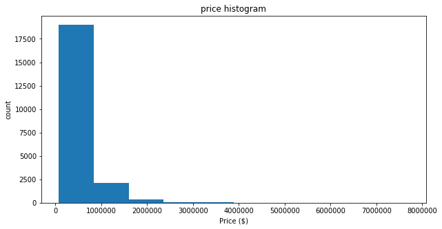

```python
plt.figure(figsize = [10,5])
binsize = 100
bins = np.arange(df.price.min(), df.price.max()+binsize, binsize)
plt.hist(data=df, x = 'price');
plt.title('price histogram')
plt.xlabel('Price ($)')
plt.ylabel('count')
```

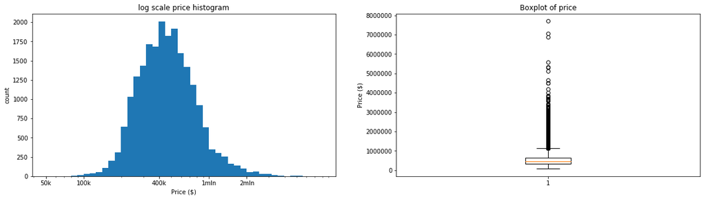

```python
# We have a long tail, let's put it on a log x-scale and boxplot

plt.figure(figsize = [20, 5])
plt.subplot(1,2,1)
log_binsize = 0.05
bins = 10 ** np.arange(np.log10(50000), np.log10(df['price'].max())+log_binsize, log_binsize)
plt.hist(data = df, x = 'price', bins = bins)
plt.xscale('log')
plt.xticks([50000, 100000, 400000, 1000000, 2000000], ['50k',  '100k', '400k', '1mln', '2mln' ])
plt.xlabel('Price ($)')
plt.title('log scale price histogram')
plt.ylabel('count')

plt.subplot(1,2,2)
plt.boxplot(data = df, x = 'price')
plt.ylabel('Price ($)')
plt.title('Boxplot of price')
plt.show()
```

*note:* log transform allows us to see normal-like distibution with a peak slightly higher 400k USD. Mainly price is between 200k USD and $ 1mln and this is suppported by the boxplot. Because of a long tail on the right and corresponding number of occurance is low consider everything above 2mln USD as outliers and let's remove it.

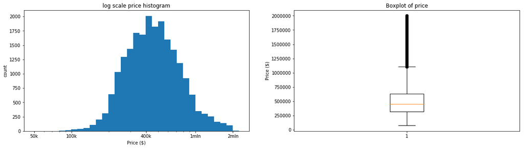

```python
df = df[df.price<2000000]

plt.figure(figsize = [20, 5])
plt.subplot(1,2,1)
log_binsize = 0.05
bins = 10 ** np.arange(np.log10(50000), np.log10(df['price'].max())+log_binsize, log_binsize)
plt.hist(data = df, x = 'price', bins = bins)
plt.xscale('log')
plt.xticks([50000, 100000, 400000, 1000000, 2000000], ['50k',  '100k', '400k', '1mln', '2mln' ])
plt.xlabel('Price ($)')
plt.title('log scale price histogram')
plt.ylabel('count')

plt.subplot(1,2,2)
plt.boxplot(data = df, x = 'price')
plt.ylabel('Price ($)')
plt.title('Boxplot of price')
plt.show()
```

We still have a long tail of outliers as we see from the boxplot. But let's keep it for visualization purposes.

Next, plot the first predictor variable sqft_living

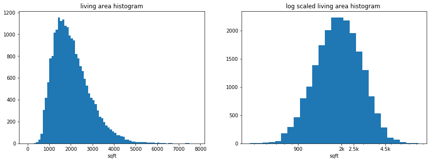

```python
# take a look at sqft_living

plt.figure(figsize = [15,5])
plt.subplot(1,2,1)
bin_size = 100
bin_edges = np.arange(0, df.sqft_living.max() +bin_size, bin_size)
plt.hist(df.sqft_living, bins = bin_edges);
plt.title('living area histogram')
plt.xlabel('sqft');

#put it in log x-scale
plt.subplot(1,2,2)
log_binsize = 0.05
bins = 10 ** np.arange(np.log10(df['sqft_living'].min()), np.log10(df['sqft_living'].max())+log_binsize, log_binsize)
plt.hist(data = df, x = 'sqft_living', bins = bins)
plt.xscale('log')
plt.xticks([900, 2000, 2500, 4500 ], ['900', '2k', '2.5k', '4.5k'])
plt.title('log scaled living area histogram ')
plt.xlabel('sqft')
plt.show()
```

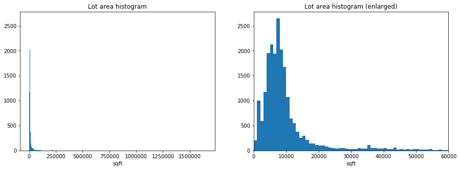

```python
# take a look at sqft_lot

plt.figure(figsize = [15,5])
plt.subplot(1,2,1)
bin_size = 1000
bin_edges = np.arange(0, df.sqft_lot.max() +bin_size, bin_size)
plt.hist(df.sqft_lot, bins = bin_edges);
plt.title('Lot area histogram')
plt.xlabel('sqft')

#draw another plot with limits 0-60000 sqft - just enlarged version of the first plot
plt.subplot(1,2,2)
bin_size = 1000
bin_edges = np.arange(0, df.sqft_lot.max() +bin_size, bin_size)
plt.hist(df.sqft_lot, bins = bin_edges);
plt.xlim(0,60000);
plt.title('Lot area histogram (enlarged)');
plt.xlabel('sqft');
```

*Note:* We can see that this histogram is very right skewed with the peak about value 8000 sqft. Again, let's check it on log-scale x-axis.

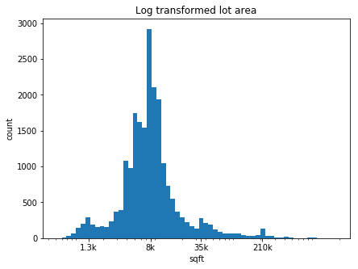

```python
plt.figure(figsize = [15,5])
plt.subplot(1,2,2)

log_binsize = 0.06

bins = 10 ** np.arange(np.log10(df['sqft_lot'].min()), np.log10(df['sqft_lot'].max())+log_binsize, log_binsize)
plt.hist(data = df, x = 'sqft_lot', bins = bins)
plt.xscale('log')
plt.xticks([1300, 8000, 35000, 210000 ], ['1.3k', '8k', '35k', '210k'])
plt.xlabel('sqft')
plt.title('Log transformed lot area')
plt.ylabel('count')
plt.show()
```

*Note:* The log-scaled histogram looks quite interesting. It is multimodal with peaks are 1.3k sqft, 35k sqft, 210k sqft with the highest peak at 8k sqft. We can see that lot area varies from 700 sqft to higher than 210k sqft.

Take a look at the above area

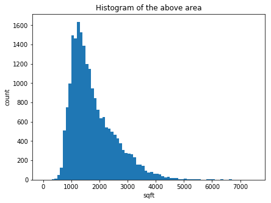

```python
plt.figure(figsize = [15,5])
plt.subplot(1,2,1)
bin_size = 100
bin_edges = np.arange(0, df.sqft_above.max() + bin_size, bin_size)
plt.hist(df.sqft_above, bins = bin_edges);
plt.title('Histogram of the above area');
plt.xlabel('sqft');
plt.ylabel('count');
```

Again, we obtained right skewed histogram. Check it on the log scale:

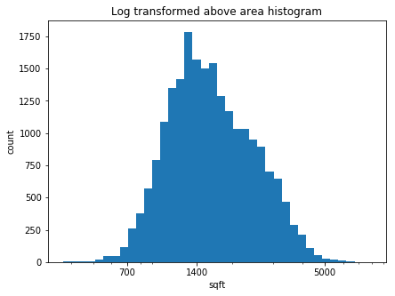

```python
plt.figure(figsize = [15,5])
plt.subplot(1,2,2)

log_binsize = 0.035

bins = 10 ** np.arange(np.log10(df['sqft_above'].min()), np.log10(df['sqft_above'].max())+log_binsize, log_binsize)
plt.hist(data = df, x = 'sqft_above', bins = bins)
plt.xscale('log')
plt.xticks([700, 1400, 5000], [700, 1400, 5000])
plt.title('Log transformed above area histogram')
plt.xlabel('sqft')
plt.ylabel('count');
plt.show()
```

*Note:* The obained histogram on log-scale looks like log-normal distribution with the peak about 1400 sqft.

Let's take a look at sqft_basement.

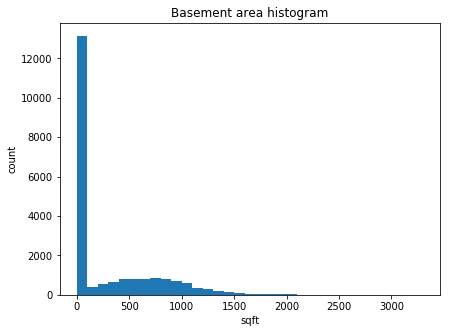

```python
plt.figure(figsize = [15,5])
plt.subplot(1,2,1)
bin_size = 100
bin_edges = np.arange(df.sqft_basement.min()-.01, df.sqft_basement.max() +bin_size, bin_size)
plt.hist(df.sqft_basement, bins = bin_edges);
plt.title('Basement area histogram')
plt.xlabel('sqft')
plt.ylabel('count');
```

Note: we can see that majority of properties do not have a basement.

Now, let's take a look at sqft_living15 and sqft_lot15 variables:

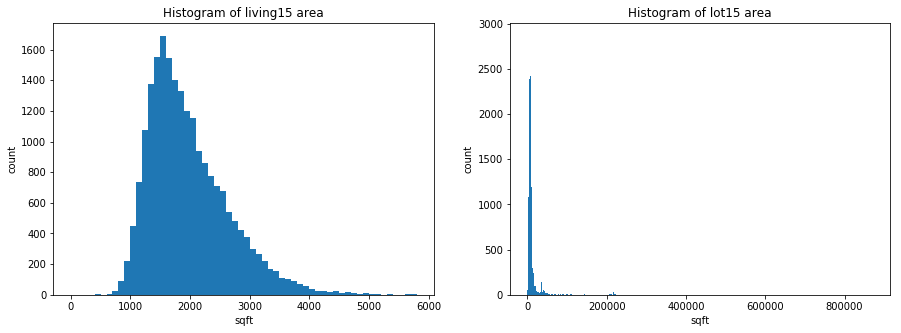

```python
plt.figure(figsize = [15,5])
plt.subplot(1,2,1)
bin_size = 100
bin_edges = np.arange(0, df.sqft_living15.max() +bin_size, bin_size)
plt.hist(df.sqft_living15, bins = bin_edges);
plt.xlabel('sqft');
plt.ylabel('count');
plt.title('Histogram of living15 area');


plt.subplot(1,2,2)
bin_size = 1000
bin_edges = np.arange(0, df.sqft_lot15.max() +bin_size, bin_size)
plt.hist(df.sqft_lot15, bins = bin_edges);
plt.xlabel('sqft');
plt.subplot(1,2,2);
plt.ylabel('count');
plt.title('Histogram of lot15 area');
```

These histograms look similar to sqft_living and sqft_lot

Take a look at barcharts of grade, condition, floors and bathrooms. Plot them on one plot.

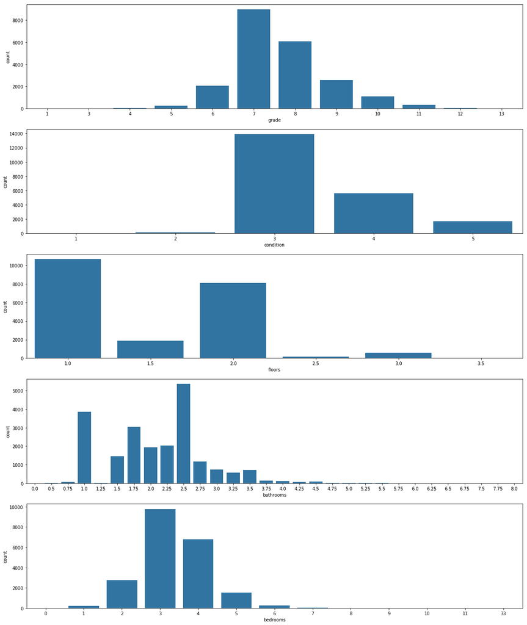

```python
fig, ax = plt.subplots(nrows = 5,  figsize = [20,25])

default_color = sb.color_palette()[0]
sb.countplot(data = df, x = 'grade', color = default_color, ax = ax[0])
sb.countplot(data = df, x = 'condition', color = default_color, ax = ax[1])
sb.countplot(data = df, x = 'floors', color = default_color, ax = ax[2])
sb.countplot(data = df, x = 'bathrooms', color = default_color, ax = ax[3])
sb.countplot(data = df, x = 'bedrooms', color = default_color, ax = ax[4])

plt.show()
```

We can see that the most common grade is 7 then 8. The most common condition specified as 3 then 4. The most often occurance of floors is 1 and then 2. 2.5 is the most often number of bathrooms in the building, then one bothrooms. Number of bothrooms higher than 3.5 are rare cases as well as 0.75 and 1.25.

## Bivariant exploration

To start off with, let's look at pairwise correlations present between features in the data.

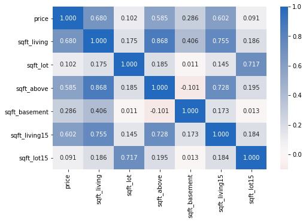

```python
numeric_vars = ['price',  'sqft_living', 'sqft_lot',  'sqft_above',
                     'sqft_basement', 'sqft_living15', 'sqft_lot15']
categoric_vars = ['bedrooms', 'bathrooms', 'floors', 'condition', 'grade', 'yr_built', 'yr_renovated']


# correlation plot
plt.figure(figsize = [8, 5])
sb.heatmap(df[numeric_vars].corr(), annot = True, fmt = '.3f',
           cmap = 'vlag_r', center = 0)
plt.show()
```

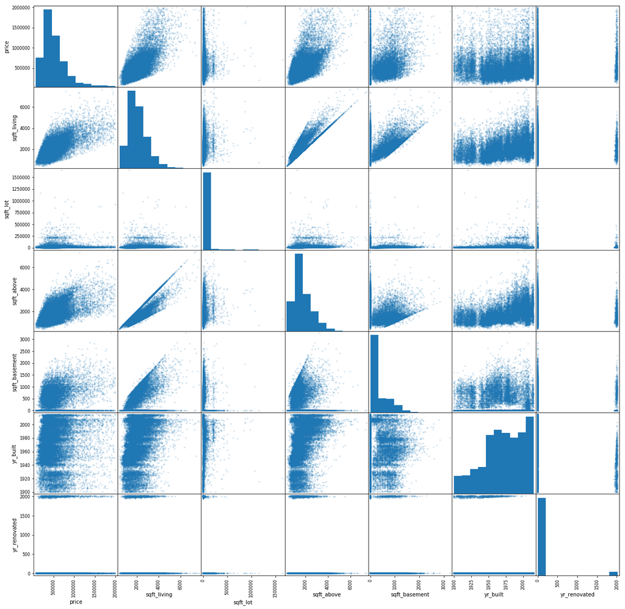

```python
pd.scatter_matrix(df[['price',  'sqft_living', 'sqft_lot',  'condition', 'grade', 'sqft_above',
                     'sqft_basement', 'yr_built', 'yr_renovated']], figsize=[20,20], alpha=0.2);
```

We can see that some veriables are correlated while others not.

- The highest correlation with the price has sqft_living - 0.68 and is classified as positive moderate correlation.
- Positive moderate correlated variables with the price are the following variables: sqft_above and sqft_living15.
- sqft_lot, sqft_lot15 and sqft_basement variables have low positive correlations.

Some predictor variables are also correltated between each other:

- sqft_living with sqft_above have high positive correlation
- sqft_living and sqft_living15 have high positive correlation
- sqft_living and sqft_basement have moderate positive correlation
- sqft_lot and sqft_lot15 have only high correlation between each other and low correlation between other features.

Let's plot a matrox of numeric features against categorical features.

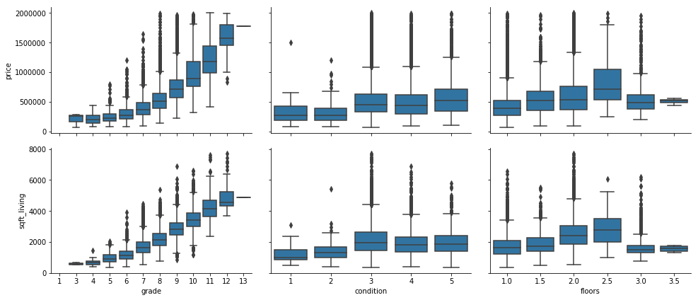

```python
def boxgrid(x, y, **kwargs):
    """ Quick hack for creating box plots with seaborn's PairGrid. """
    default_color = sb.color_palette()[0]
    sb.boxplot(x, y, color = default_color)

plt.figure(figsize = [10, 10])
g = sb.PairGrid(data = df, y_vars = ['price', 'sqft_living'], x_vars = ['grade', 'condition', 'floors'],
                size = 3, aspect = 1.5);
g.map(boxgrid);
plt.show();
```

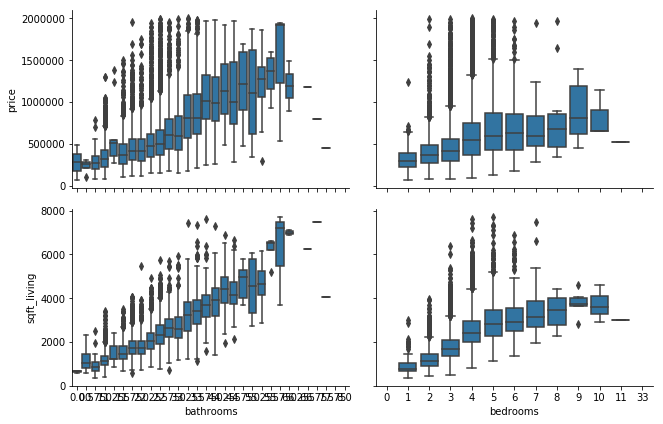

```python
def boxgrid(x, y, **kwargs):
    """ Quick hack for creating box plots with seaborn's PairGrid. """
    default_color = sb.color_palette()[0]
    sb.boxplot(x, y, color = default_color)

plt.figure(figsize = [10, 10])
g = sb.PairGrid(data = df, y_vars = ['price', 'sqft_living'], x_vars = [ 'bathrooms', 'bedrooms'],
                size = 3, aspect = 1.5);
g.map(boxgrid);
plt.show();
```

*Note:*

- We can see that on average grade with price and living area has parabolic relationship.
- On everage condition does not effect price that much.
- On everage the price increased 3 and stays at almost the same after that.
- It is interesting that on evarage price and living area are increasing as number of floors increasing from 1 to 2.5; however, the price and living area drop at 3 and 3.5 floors
- The price and living area have linear relationship with bathrooms. It is natural to have higher number of bathrooms when living area is bigger.
- The higher number of bedrooms is assosieated with higher price and bigger living area. This is also intuitively we can expect.

Let's look at relationship between grade and bedrooms, grade and condition

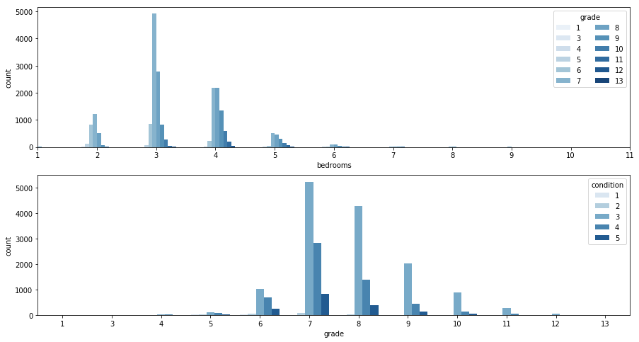

```python
plt.figure(figsize=[15,8])

# subplot 1: clarity vs. color, use different color palette
ax = plt.subplot(2, 1, 1)
sb.countplot(data = df, x = 'bedrooms', hue = 'grade', palette = 'Blues' )
ax.legend(loc = 1, ncol = 2, title = 'grade') # re-arrange legend to remove overlapping
plt.xlim(1,11)


# subplot 2:
ax = plt.subplot(2, 1, 2)
sb.countplot(data = df, x = 'grade', hue = 'condition', palette = 'Blues')
ax.legend(loc = 1, title="condition") # re-arrange legend to remove overlapping
plt.show()
```

We can see that the most popular number of bedrooms is 3. Grades 7 and 8 are the most common for number of bedrooms 2-6. We don't see dependance that higher number of rooms the higher grade.

The most common grade is 7. For grades 5-11 the most common condition is 3 (medium). We don't see relationship such as the higher grade the better condition.

Check correlation between living area and price

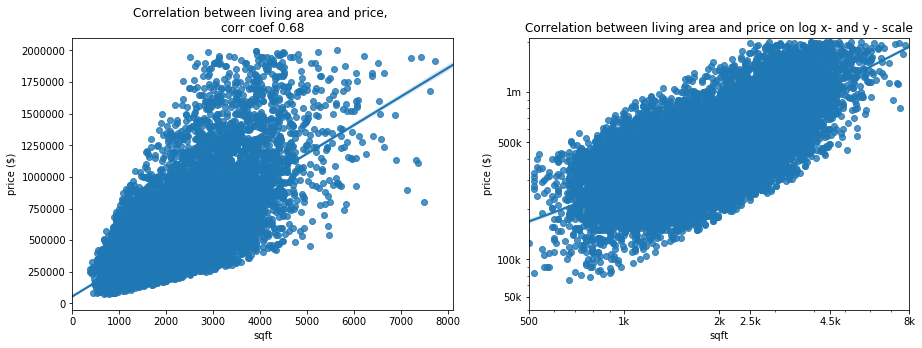

```python
plt.figure(figsize = [15,5])

plt.subplot(1,2,1)
sb.regplot(data = df, x=df.sqft_living, y=df.price);
plt.title('Correlation between living area and price, \ncorr coef {:4.2f}'.format(df[['sqft_living', 'price']].corr().iloc[0,1]));
plt.xlabel('sqft');
plt.ylabel('price ($)');

plt.subplot(1,2,2)
log_binsize_x = 0.05
log_binsize_x = 0.05
bins_x = 10 ** np.arange(np.log10(df['sqft_living'].min()), np.log10(df['sqft_living'].max())+log_binsize_x, log_binsize_x)
bins_y = 10 ** np.arange(np.log10(df['price'].min()), np.log10(df['price'].max())+log_binsize_x, log_binsize_x)
sb.regplot(x=df.sqft_living, y=df.price, data =df);
plt.xscale('log')
plt.yscale('log')
plt.xticks([500, 1000, 2000, 2500, 4500, 8000 ], ['500', '1k','2k', '2.5k', '4.5k', '8k'])
plt.yticks([60e3, 100e3, 500e3, 1e6], ['50k', '100k', '500k', '1m'])
plt.xlim(500,8000);
plt.ylim(50000,2100000);
plt.xlabel('sqft');
plt.ylabel('price ($)');
plt.title('Correlation between living area and price on log x- and y - scale');
```

We can see that there is a correlation between living area and price with correlation coefficient 0.68; moreover, on the log scale such relationship looks more linear.

Check correlation between price and lot area and price and lot15 area

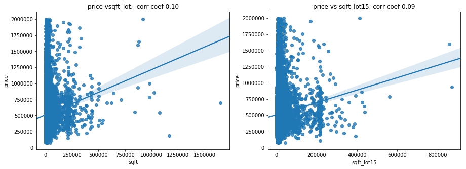

```python
plt.figure(figsize = [15,5])
plt.subplot(1,2,1)
sb.regplot(data = df, x=df.sqft_lot, y=df.price);
plt.title('price vsqft_lot,  corr coef {:4.2f}'.format(np.corrcoef(x=df.sqft_lot, y=df.price)[0,1]))
plt.xlabel('sqft')


plt.subplot(1,2,2)
sb.regplot(data = df, x=df.sqft_lot15, y=df.price);
plt.title('price vs sqft_lot15, corr coef {:4.2f}'.format(np.corrcoef(x=df.sqft_lot15, y=df.price)[0,1]));
```

We can see that there low positive correlation with correlation coefficient about 0.1

Let's consider price vs living area and price vs living15 area

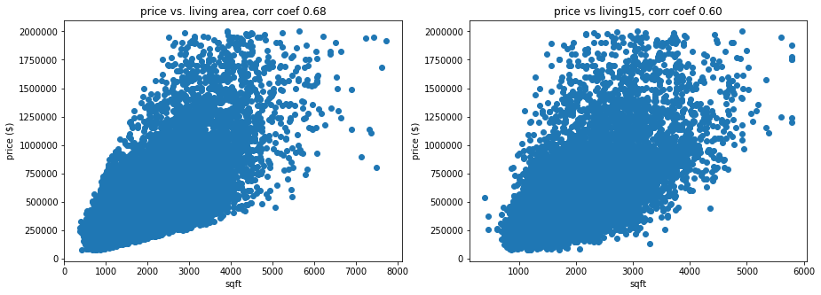

```python
plt.figure(figsize = [15,5])
plt.subplot(1,2,1)
plt.scatter(x=df.sqft_living, y=df.price);
plt.title('price vs. living area, corr coef {:4.2f}'.format(np.corrcoef(x=df.sqft_living, y=df.price)[0,1]));
plt.xlabel('sqft');
plt.ylabel('price ($)');

plt.subplot(1,2,2)
plt.scatter(x=df.sqft_living15, y=df.price);
plt.title('price vs living15, corr coef {:4.2f}'.format(np.corrcoef(x=df.sqft_living15, y=df.price)[0,1]));
plt.xlabel('sqft');
plt.ylabel('price ($)');
```

We can see that plots have similar behavior with positive moderate correlation. However, correlation for the first plot is higher and equil to 0.68

Consider correlation between living area vs above area and living area vs badement area

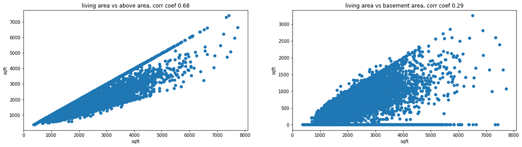

```python
plt.figure(figsize = [20,5])


plt.subplot(1,2,1)
plt.scatter(x=df.sqft_living, y=df.sqft_above);
plt.title('living area vs above area, corr coef {:4.2f}'.format(np.corrcoef(x=df.sqft_living, y=df.price)[0,1]));
plt.xlabel('sqft');
plt.ylabel('sqft');


plt.subplot(1,2,2)
plt.scatter(x=df.sqft_living, y=df.sqft_basement);
plt.title('living area vs basement area, corr coef {:4.2f}'.format(np.corrcoef(x=df.sqft_basement, y=df.price)[0,1]));
plt.xlabel('sqft');
plt.ylabel('sqft');
```

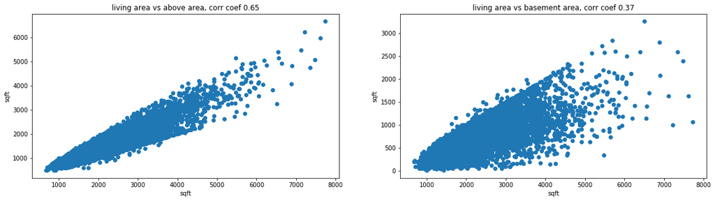

```python
plt.figure(figsize = [20,5])


plt.subplot(1,2,1)
plt.scatter(x=df.query('sqft_basement>0').sqft_living, y=df.query('sqft_basement>0').sqft_above);
plt.title('living area vs above area, corr coef {:4.2f}'.format(np.corrcoef(x=df.query('sqft_basement>0').sqft_living, y=df.query('sqft_basement>0').price)[0,1]));
plt.xlabel('sqft');
plt.ylabel('sqft');


plt.subplot(1,2,2)
plt.scatter(x=df.query('sqft_basement>0').sqft_living, y=df.query('sqft_basement>0').sqft_basement);
plt.title('living area vs basement area, corr coef {:4.2f}'.format(np.corrcoef(x=df.query('sqft_basement>0').sqft_basement, y=df.query('sqft_basement>0').price)[0,1]));
plt.xlabel('sqft');
plt.ylabel('sqft');
```

Now, let's consider the correlation of price with living, basement and above when basement area is not 0

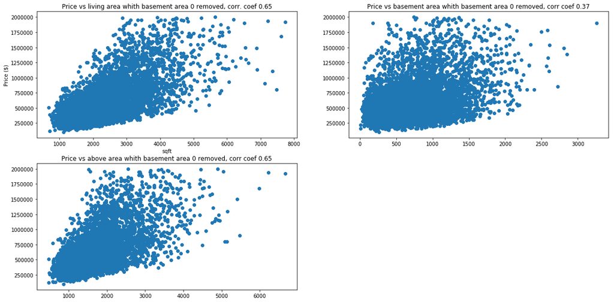

```python
plt.figure(figsize = [20,10])


plt.subplot(2,2,1)
plt.scatter(x=df.query('sqft_basement>0').sqft_living, y=df.query('sqft_basement>0').price);
plt.title('Price vs living area whith basement area 0 removed, corr. coef {:4.2f}'.format(np.corrcoef(x=df.query('sqft_basement>0').sqft_living, y=df.query('sqft_basement>0').price)[0,1]));
plt.xlabel('sqft')
plt.ylabel('Price ($)')

plt.subplot(2,2,2)
plt.scatter(x=df.query('sqft_basement>0').sqft_basement, y=df.query('sqft_basement>0').price);
plt.title('Price vs basement area whith basement area 0 removed, corr coef {:4.2f}'.format(np.corrcoef(x=df.query('sqft_basement>0').sqft_basement, y=df.query('sqft_basement>0').price)[0,1]));

plt.subplot(2,2,3)
plt.scatter(x=df.query('sqft_basement>0').sqft_above, y=df.query('sqft_basement>0').price);
plt.title('Price vs above area whith basement area 0 removed, corr coef {:4.2f}'.format(np.corrcoef(x=df.query('sqft_basement>0').sqft_above, y=df.query('sqft_basement>0').price)[0,1]));
```

We can see that plots price vs living area and price vs above area look pretty similar. Moreover, they have the same correlation coefficients. The relationship price vs basement area has correlation coefficient 0.37, which is positive moderate coefficient.

Now, let's consider case when basement is 0 for Price vs living area and Price vs above area

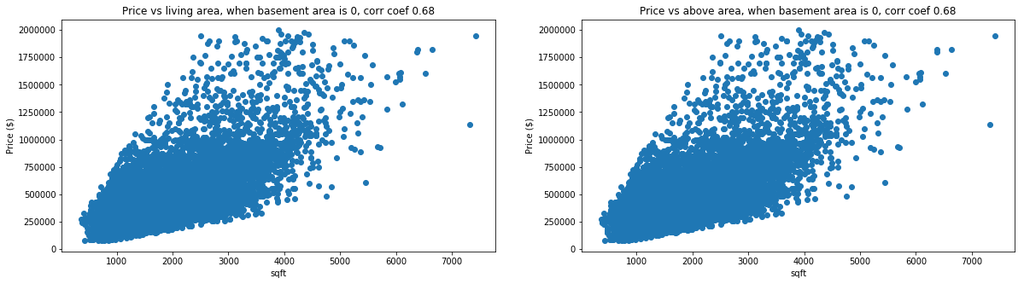

```python
plt.figure(figsize = [20,5])


plt.subplot(1,2,1)
plt.scatter(x=df.query('sqft_basement==0').sqft_living, y=df.query('sqft_basement==0').price);
plt.title('Price vs living area, when basement area is 0, corr coef {:4.2f}'.format(np.corrcoef(x=df.query('sqft_basement==0').sqft_living, y=df.query('sqft_basement==0').price)[0,1]));
plt.ylabel('Price ($)');
plt.xlabel('sqft');

plt.subplot(1,2,2)
plt.scatter(x=df.query('sqft_basement==0').sqft_above, y=df.query('sqft_basement==0').price);
plt.title('Price vs above area, when basement area is 0, corr coef {:4.2f}'.format(np.corrcoef(x=df.query('sqft_basement==0').sqft_above, y=df.query('sqft_basement==0').price)[0,1]));
plt.ylabel('Price ($)');
plt.xlabel('sqft');
```

```python
df.query('sqft_basement==0')[['sqft_living', 'sqft_above']].sample(5)
```

|  | sqft_living | sqft_above |
| --- | --- | --- |
| 2052 | 1720 | 1720 |
| 2609 | 1850 | 1850 |
| 1971 | 940 | 940 |
| 12061 | 2120 | 2120 |
| 16901 | 1300 | 1300 |

Let's consider relationship between sqft_living and price with respect to condition and grade. Violin plot will be plotted.

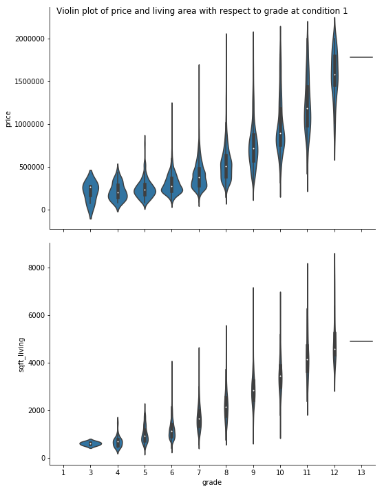

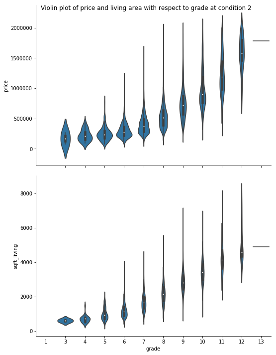

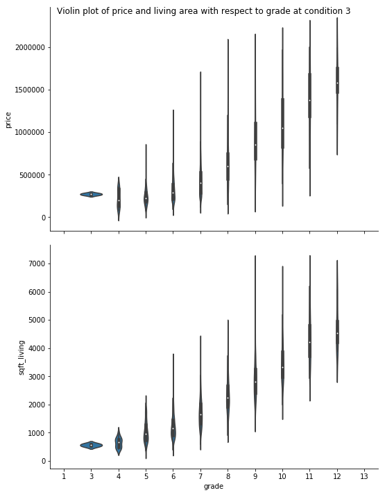

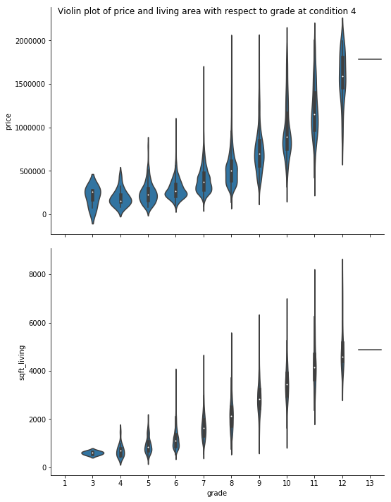

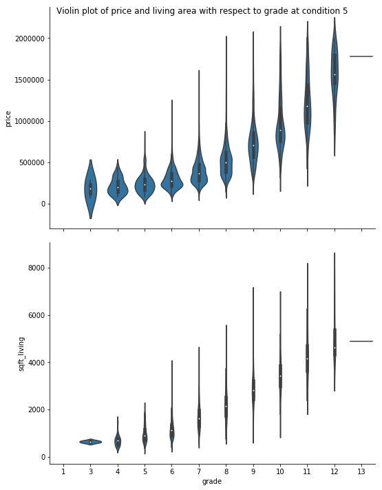

```python
def hist2dgrid(x, y, **kwargs):
    """ Quick hack for creating heat maps with seaborn's PairGrid. """
    palette = kwargs.pop('color')
    #bins_x = np.arange(cuberoot_trans(.2), cuberoot_trans(3.5)+.05, .05)
    #bins_y = np.arange(2.4, 4.3+0.1, 0.1)
    #plt.hist2d(x, y, cmap = palette, cmin = 0.5)  # bins = [bins_x, bins_y],
    sb.violinplot(x, y, color = default_color)
#    plt.title('Violin plot of price and living area with respect to grade at condition 1')
    #plt.xticks(cuberoot_trans(np.array(carat_ticks)), carat_ticks)
    #plt.yticks(log_trans(np.array([500, 1e3, 2e3, 5e3, 1e4, 2e4])),
               #[500, '1k', '2k', '5k', '10k', '20k'])




df_temp1 = df.drop(df.query('condition == [1]').index).copy()

g = sb.PairGrid(data = df_temp1, y_vars = ['price', 'sqft_living'], x_vars = 'grade',
                size = 5, aspect = 1.5)
g.map(hist2dgrid)
g.fig.suptitle('Violin plot of price and living area with respect to grade at condition 1')


df_temp2 = df.drop(df.query('condition == [2]').index).copy()
g = sb.PairGrid(data = df_temp2, y_vars = ['price', 'sqft_living'], x_vars = 'grade',
                size = 5, aspect = 1.5)
g.map(hist2dgrid)
g.fig.suptitle('Violin plot of price and living area with respect to grade at condition 2')


df_temp3 = df.drop(df.query('condition == [3]').index).copy()
g = sb.PairGrid(data = df_temp3, y_vars = ['price', 'sqft_living'], x_vars = 'grade',
                size = 5, aspect = 1.5)
g.map(hist2dgrid)
g.fig.suptitle('Violin plot of price and living area with respect to grade at condition 3')

df_temp4 = df.drop(df.query('condition == [4]').index).copy()
g = sb.PairGrid(data = df_temp4, y_vars = ['price', 'sqft_living'], x_vars = 'grade',
                size = 5, aspect = 1.5)
g.map(hist2dgrid)
g.fig.suptitle('Violin plot of price and living area with respect to grade at condition 4')

df_temp5 = df.drop(df.query('condition == [5]').index).copy()


g = sb.PairGrid(data = df_temp5, y_vars = ['price', 'sqft_living'], x_vars = 'grade',
                size = 5, aspect = 1.5)
g.map(hist2dgrid)
g.fig.suptitle('Violin plot of price and living area with respect to grade at condition 5')
```

Following white points on the drawn violins which are median of the distribution we can identify a parabolic dependancy where the price increase about 300000 USD upto 1500000 USD. We can see that when grades get higher the tails get longer on distributions. We can say that if the grade is equil to 7 or less than the prices are bounded by the upper limit - around 500000 USD. We can also argue that price depends on condition, but it is not as noticible as the dependence on the grade.

We have similar picture for the living area. As grade increase the living area increasing on average and also have parabolic-like dependance. At grade 7 or lower the area has an upper bound abour 2000 sqft.

Let's consider dependence of the average price with respect to the month when the property is sold, condition and grade.

```python
df['month_year'] = 'data'
months = ['Jan', 'Feb', 'Mar', 'Apr', 'May', 'Jun', 'Jul', 'Aug', 'Sep', 'Oct', 'Nov', 'Dec']
month_year_list =[]

for year in pd.DatetimeIndex(df['date']).year.unique():
    for month in pd.DatetimeIndex(df['date']).month.unique():
        month_year = months[month-1] + " " + str(year)
        month_year_list.append(month_year)
        df.loc[(pd.DatetimeIndex(df['date']).year == year) & (pd.DatetimeIndex(df['date']).month == month), 'month_year'] = month_year


month_year_list = ['May 2014',  'Jun 2014', 'Jul 2014', 'Aug 2014','Sep 2014', 'Oct 2014', 'Nov 2014', 'Dec 2014',
                  'Jan 2015', 'Feb 2015', 'Mar 2015', 'Apr 2015', 'May 2015' ]

price_mean_month = df.groupby(['month_year', 'condition', 'grade']).mean()['price']
price_mean_month = price_mean_month.reset_index(name = 'mean_price');
price_mean_month.dropna(inplace=True)
```

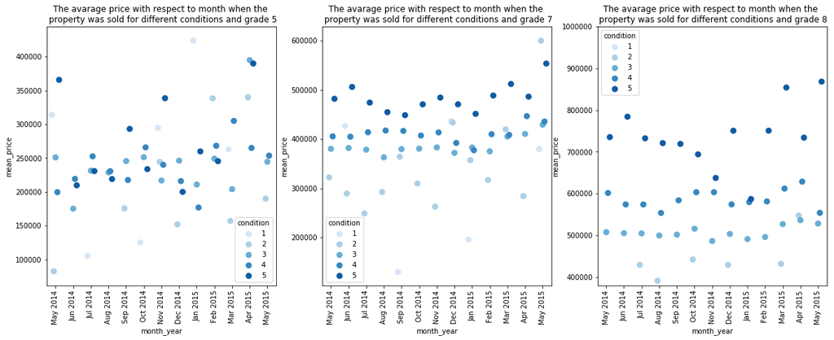

```python
plt.figure(figsize =[20,15])



plt.subplot(2,3,1)

sb.pointplot(data = price_mean_month.query('grade==5'), x = 'month_year', y = 'mean_price',
             hue='condition', linestyles="", order=month_year_list, dodge = 0.4, palette = 'Blues');
plt.xticks(rotation=90);
plt.title('The avarage price with respect to month when the \n property was sold for different conditions and grade 5')

plt.subplot(2,3,2)

sb.pointplot(data = price_mean_month.query('grade==7'), x = 'month_year', y = 'mean_price',
             hue = 'condition', linestyles="", order=month_year_list, dodge = 0.4, palette = 'Blues');
plt.xticks(rotation=90);
plt.title('The avarage price with respect to month when the \n property was sold for different conditions and grade 7')


plt.subplot(2,3,3)

sb.pointplot(data = price_mean_month.query('grade==8'), x = 'month_year', y = 'mean_price',
             hue = 'condition', linestyles="", order=month_year_list, dodge = 0.4, palette = 'Blues');
plt.xticks(rotation=90);
plt.title('The avarage price with respect to month when the \n property was sold for different conditions and grade 8')
plt.ylim(380000, 1e6);
```

```python
df['yr_built_range'] = pd.cut(df.yr_built, [1933, 1934, 1935, 1940, 1945, 1950, 1955, 1960, 1965 , 1970, 1975, 1980, 1985, 1990,
                                      1995, 2000, 2005, 2010, 2015])
```

```python
order = ['1935-1940', '1941-1945', '1946-1950', '1951-1955', '1956-1960', '1961-1965', '1966-1970', '1971-1975', '1976-1980', '1981-1985', '1986-1990', '1991-1995', '1996-2000','2001-2005', '2006-2010', '2011-2015']
```

Let's consider the average price with respect to the year built and condition.

```python
price_mean_yr_built = df.groupby(['yr_built_range', 'condition']).mean()['price']
price_mean_yr_built = price_mean_yr_built.reset_index(name = 'mean_price');
price_mean_yr_built=price_mean_yr_built.dropna().copy()
```

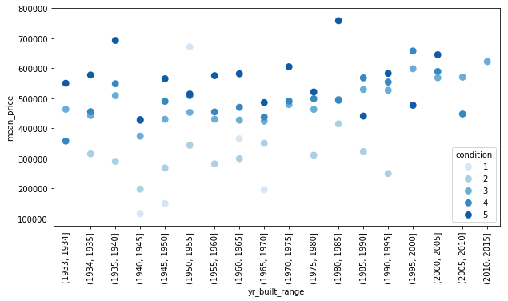

```python
plt.figure(figsize=[10,5])
sb.pointplot(data = price_mean_yr_built, x = 'yr_built_range', y = 'mean_price', hue = 'condition', linestyles="", palette = 'Blues');
plt.xticks(rotation=90);
```

Here we can see that the better condition the higher average price.Also, one can see an uptrend in the price as older the property it is cheaper. In addition, we can see that some old properties with condition 5 are expensive and even cost higher than newer ones.

Let's consider average price with respect to year of renovation and condition.

```python
df['yr_renovated_range'] = pd.cut(df.yr_renovated, [0, 1933, 1934, 1935, 1940, 1945, 1950, 1955, 1960, 1965 , 1970, 1975, 1980, 1985, 1990,
                                      1995, 2000, 2005, 2010, 2015])
order = [0, '1934-1940', '1941-1945', '1946-1950', '1951-1955', '1956-1960', '1961-1965', '1966-1970', '1971-1975', '1976-1980', '1981-1985', '1986-1990', '1991-1995', '1996-2000','2001-2005', '2006-2010', '2011-2015']
```

```python
price_mean_yr_renovated = df.groupby(['yr_renovated_range', 'condition']).mean()['price']
price_mean_yr_renovated = price_mean_yr_renovated.reset_index(name = 'mean_price');
price_mean_yr_renovated=price_mean_yr_renovated.dropna()
```

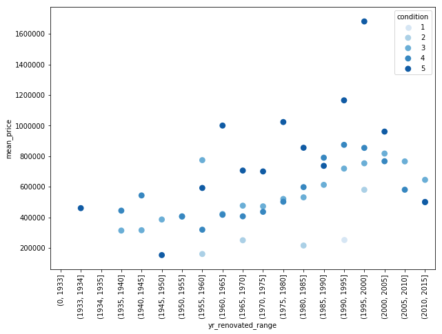

```python
plt.figure(figsize=[10,7])
sb.pointplot(data = price_mean_yr_renovated, x = 'yr_renovated_range', y = 'mean_price', hue = 'condition', linestyles="",palette = 'Blues');
plt.xticks(rotation=90);
```

We can see that later was renovation of the property the higher average prices. Again, the better condition the price is higher. In addition, we can see that if the innovation was completed durin the last 15-20 year the price decline.

Let's consider prices with respect to living area and waterfront.

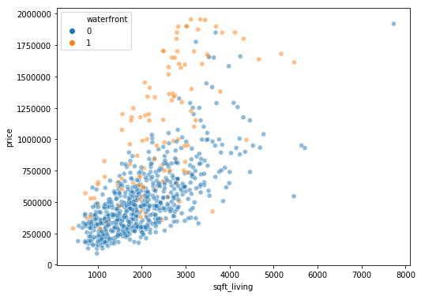

```python
plt.figure(figsize = [8,6])
df_waterfront = df.query('waterfront == 1')
df_no_waterfront = df.query('waterfront == 0').sample(frac=0.03) # sampe dataset to have a better veiew of the plot without overlapping
df_waterfront = pd.concat([df_waterfront, df_no_waterfront])
sb.scatterplot(df_waterfront.sqft_living, df_waterfront.price, hue = df.waterfront, alpha=0.5);
```

We can see that properties with waterfront, idndicated by orange dots, have usually higher price among the propeties with similar living area.